# 4M074 Probabilités Numériques et Statistique Computationnelle

DU Qiming email : duqiming2004@gmail.com or qiming.du@upmc.fr

printemps 2019

Ce qui précède correspond à une liste de questions posées par les étudiants pendant le TP (groupe B1 de 4M015 2017). Comme il y a beaucoup de possibilités pour faire des codes **jolis**, je trouve qu’il est plus raisonnable d’apprendre les détails petit à petit. Je sélectionne les problèmes qui sont (sans doute) intéressants pour qu’on puisse avancer ensemble.

N’hésitez pas à m’envoyer un email pour poser des questions.

**misc:**

- [cette page](https://github.com/mgimm/TP)
- [Un Rmd template](https://github.com/mgimm/Rmd-template/) [(preview)](https://mgimm.github.io/Rmd-template/)
- [Un livre très très bon pour les débutants d’info (surtout nous : les étudiants de maths)](https://info201.github.io/index.html)
- [LPSM simulation](http://simulations.lpsm.paris/)

**Annales du TP noté:**

- [TP noté I 2017](https://github.com/MGIMM/TP/raw/master/doc/TPnote2017.zip)
- [TP noté I 2018](https://github.com/MGIMM/TP/raw/master/doc/TPnote2018.zip)

# 1 Environnements de `R`

On travaille principalement sur [Jupyter Notebook](https://jupyter.readthedocs.io/en/latest/index.html) avec [IRkernel](https://irkernel.github.io/). Vous pouvez aussi utiliser [Rstudio](https://www.rstudio.com/). Voici un guide pour l'installation de Jupyter et IRkernel pour tous les OS.

[Installation de Python et Jupyter](https://mgimm.github.io/blog/misc/2016/11/17/Installation-python/)

Si vous avez des problèmes sur la configuration, n'hésitez pas à me demander De plus, [sagecloud](https://cloud.sagemath.com/settings) permet de compiler les notebooks en ligne (gratuit).

## 1.1 Conseils pour les débudants de `R`

Si vous n'avez jamais suivi un cours de `R`, vous trouvrez dans les liens suivants deux documents par madame Tabea Rebafka pour le cours 4M015.

- [Prise en main de R](https://mgimm.github.io/blog/public/pdf/Prise_en_main_de_R.pdf)
- [Programmation en R](https://mgimm.github.io/blog/public/pdf/Programmation_en_R.pdf)

# 2 R de base

## 2.1 Matrices des figures

Cas simple :

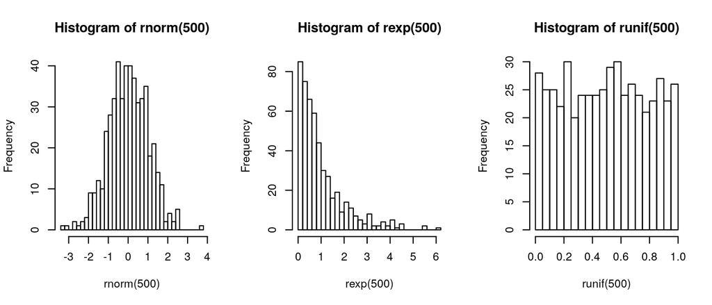

Figure 1: Matrice d’histogrammes

```r
par(mfrow=c(1,3))
hist(rnorm(500), breaks=30)
hist(rexp(500), breaks=30)
hist(runif(500), breaks=30)
```

Cas (un peu) compliqué:

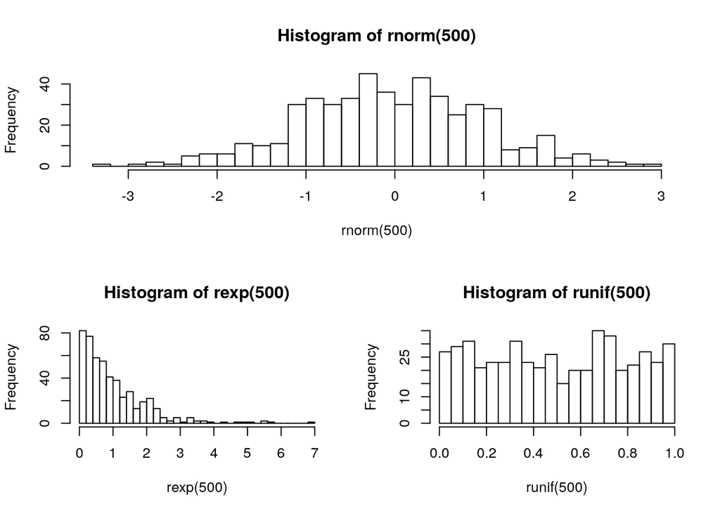

Figure 2: Matrice d’histogrammes

```r
# One figure in row 1 and two figures in row 2
layout(matrix(c(1,1,2,3), 2, 2, byrow = TRUE))
hist(rnorm(500), breaks=30)
hist(rexp(500), breaks=30)
hist(runif(500), breaks=30)
```

## 2.2 `lines` et `curve`

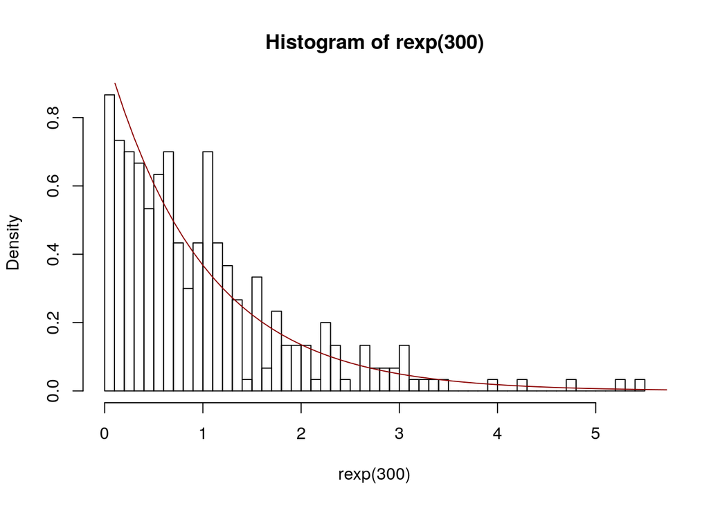

Figure 3: ex. de la fonction *lines*

```r
hist(rexp(300), freq=FALSE, breaks = 40)
x<-seq(0,8,by=.1)
# ici, x est un vecteur
lines(x, dexp(x), col = 'darkred')
```

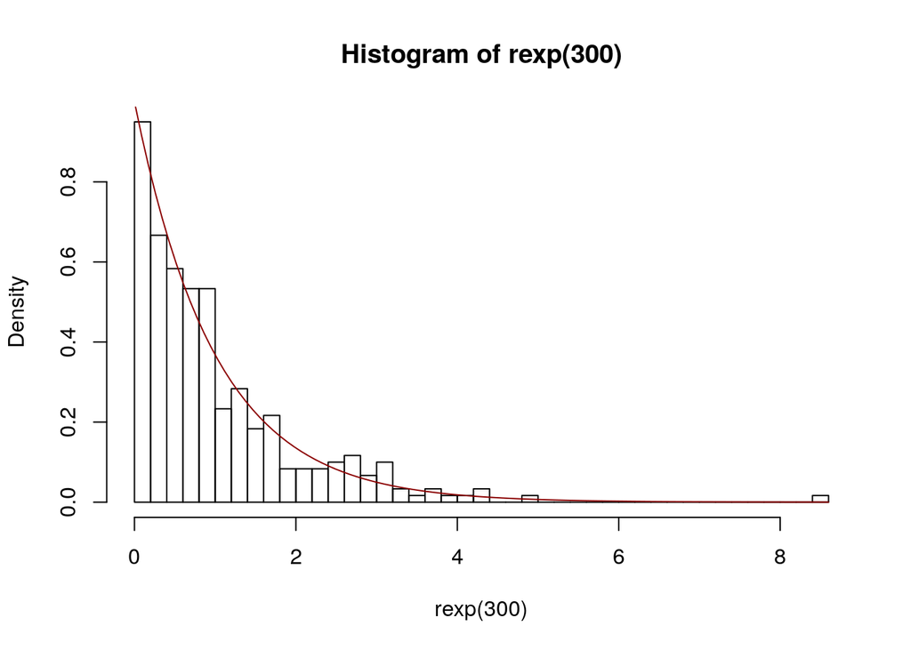

Figure 4: ex. de la fonction *curve*

```r
hist(rexp(300), freq=FALSE, breaks = 40)
# ici, x est qqch abstrait
# pour aller plus loin  ?expression
curve(dexp(x), col = 'darkred', add=TRUE, from=.001)
```

## 2.3 `list` to `data.frame`

```r
a <- list()
b <- list()
a$X <- 1
a$Y <- 2
b$X <- 3
b$Y <- 4
data.frame(do.call(rbind, list(a,b)))
```

```
##   X Y
## 1 1 2
## 2 3 4
```